# Visualization Tycho 2.0

Tushal Kakadiya [804775, tushal.kakadiya@stud.th-deg.de]

Jishnu Vamanan [806002, jishnu.vamanan@stud.th-deg.de]

07-07-2022

[figure not shown]

# 1.Introduction

Diseases are considered to be a part of life not only for humans but also for all living organisms. One will be affected by one or more diseases at least once in their lifespan. Either it will be a genetic one or it can be the after-effects of the contaminated living environment. Most of the diseases which are caused by external matters that enter our body could be treated by the body itself through its Immunol response or with medical treatments.

It is known that the human race has been facing many kinds of diseases in the past and as the lifestyle of mankind changes, diseases also seem to take new roles. In case of Covid 19 disease, this is considered to be a dreadful disease that led to a global pandemic. Studies of history of diseases shows that it is not the first time the world has faced a pandemic situation. Many diseases shook the world with their ability to spread and affect human life expectancy.

Life expectancy is one of the most commonly used measures for international health comparison. In 2007, the United States ranked 27th and 26th out of 33 countries within its peer group of Organization for Economic Co-operation and Development (OECD) countries for life expectancy at birth for females and males, respectively [1](https://www.healthypeople.gov/2020/about/foundation-health-measures/General-Health-Status).

This project is aiming to analyze massive data that contains the details of 50 diseases that occurred in all states of the U.S during the time 1888 to 2014. The Source of this data is from Project Tycho which works with national and global health institutes and researchers to make data easier to use and free to access for public to do analysis and research.

When it comes to interpreting an enormous amount of data, Data Visualization becomes the most desirable way. Rather than screening huge Excel sheets, it is always better to visualize that data through graphical representation, to gain meaningful insights.

# 2.Problem Defenition

From the data of Tycho 2.0, analysis could be done to find out if there are any hidden enlightenment in the data. This data provides numerous opportunities for research on 50 disease which had impact on U.S. so the point of interest has to be set to certain areas so that some good quality analysis from this work can be obtained. To reach out the above-said criteria, the research tries to find out the type of disease which is most abundant in the U.S country during the years 1888 to 2014 and also which state were affected.

# 3.Objectives

The goal is to investigate the nature of disease spread in each of the United States’ 50 states. The first step is to interpret and attempt to comprehend the relationships between data formats, columns, and actual data. The data could aid in the development of statistical analyses as well as graphical visualizations and interpretations of the relationships between events and effects.

# 4.Methods

R provides quick and simple tools that make it easier to transform data into visually insightful pieces like graphs. The data gets easier to read and comprehend from the graphs. The following is a list of the various types of graphs are plotted here using Descriptive statistics and ggplot2.

Tree Map: A Tree map displays hierarchical data as a set of nested rectangles. Each group is represented by a rectangle, which area is proportional to its value.

Geom Map: Used to display the data in the Map (In this case the U.S map)

Bar plot: A bar chart presents categorical data with rectangular bars with heights or lengths proportional to the values that they represent.

Box plot: A box plot shows the distribution of numerical data and skewness through displaying data averages.

Heat Map: A heat map is a two-dimensional representation of data in which values are represented by color gradients.

Animation Plot: A animation plot makes easy to represent data distribution over time period.

# 5. Data Analysis

The data analyses are done in different steps which are explained in detail as follows.

## 5.1 Loading the libraries

Here are all the libraries has used in this work.

```r
library (ggplot2)
library (ggthemes)
library (readr)
library (dplyr)
library (tidyverse)
library (ggpubr)
library (treemap)
library (usmap)
library (gapminder)
library (gganimate)
library (treemap)
library (ggridges)
options(scipen=999999) # It disables the scientific notion
```

## 5.2 Loading the Data

Below code is used to set the working directory and the create a new file that contains the required data that has tp be analysed.

```r
setwd("D:/LSI/Life Science Info. SS 2022/Data Visulization") # Setting working directory

Tycho <- read.csv("ProjectTycho_Level2_v1.1.0.csv", header = T, stringsAsFactors = T) # Loading data in csv File
```

## 5.3 Checking the Data, rearranging and clean ups

The next step is to look into the data and study the dimensions and contents in the data. The scattered data is rearranged, cleaned up as it is ready for the analysis.

```r
dim(Tycho) # Dimension of the data in rows followed by columns
```

```
## [1] 3659360      11
```

```r
Tycho <- Tycho %>% arrange(epi_week) #Arranging data by time sires from 1888 to 2014

head(Tycho)
```

|  | epi_week | country | state | loc | loc_type | disease | event | number | from_date | to_date | url |
| --- | --- | --- | --- | --- | --- | --- | --- | --- | --- | --- | --- |
| 1 | 188737 | US | KY | LOUISVILLE | CITY | TYPHOID FEVER [ENTERIC FEVER] | DEATHS | 3 | 1887-09-09 | 1887-09-15 | http://www.ncbi.nlm.nih.gov/pmc/articles/PMC2084180 |
| 2 | 188823 | US | OH | CLEVELAND | CITY | TYPHOID FEVER [ENTERIC FEVER] | DEATHS | 1 | 1888-06-03 | 1888-06-09 | http://www.ncbi.nlm.nih.gov/pmc/articles/PMC2084172 |
| 3 | 188823 | US | OH | CLEVELAND | CITY | SCARLET FEVER | DEATHS | 1 | 1888-06-03 | 1888-06-09 | http://www.ncbi.nlm.nih.gov/pmc/articles/PMC2084172 |
| 4 | 188823 | US | OH | CLEVELAND | CITY | DIPHTHERIA | DEATHS | 5 | 1888-06-03 | 1888-06-09 | http://www.ncbi.nlm.nih.gov/pmc/articles/PMC2084172 |
| 5 | 188824 | US | PA | PHILADELPHIA | CITY | TYPHOID FEVER [ENTERIC FEVER] | DEATHS | 14 | 1888-06-10 | 1888-06-16 | http://www.ncbi.nlm.nih.gov/pmc/articles/PMC2084171 |
| 6 | 188824 | US | PA | PHILADELPHIA | CITY | SCARLET FEVER | DEATHS | 4 | 1888-06-10 | 1888-06-16 | http://www.ncbi.nlm.nih.gov/pmc/articles/PMC2084171 |

```r
Tycho <- Tycho[ , -11] # Deletion of column num. 11 url

Tycho <- Tycho[ , -2] # Deletion of column num. 2 US
```

```r
Tycho <- Tycho %>% filter(number > 0 ) # removing 0 cases or deaths from the Tycho 36,59,360 - 26,78,605 = 9,80,755 rows has 0 cases data.
```

```r
str(Tycho)# checking the data type of each column
```

```
## 'data.frame':    2678605 obs. of  9 variables:
##  $ epi_week : int  188737 188823 188823 188823 188824 188824 188824 188824 188824 188824 ...
##  $ state    : Factor w/ 57 levels "AK","AL","AR",..: 20 39 39 39 42 42 42 39 39 42 ...
##  $ loc      : Factor w/ 630 levels "ABERDEEN","ADAMS",..: 325 123 123 123 465 465 465 123 123 465 ...
##  $ loc_type : Factor w/ 2 levels "CITY","STATE": 1 1 1 1 1 1 1 1 1 1 ...
##  $ disease  : Factor w/ 50 levels "ANTHRAX","BABESIOSIS",..: 46 46 36 11 46 36 11 46 11 38 ...
##  $ event    : Factor w/ 2 levels "CASES","DEATHS": 2 2 2 2 2 2 2 2 2 2 ...
##  $ number   : int  3 1 1 5 14 4 4 3 5 3 ...
##  $ from_date: Factor w/ 10557 levels "1887-09-09","1888-06-03",..: 1 2 2 2 3 3 3 3 3 3 ...
##  $ to_date  : Factor w/ 10557 levels "1887-09-15","1888-06-09",..: 1 2 2 2 3 3 3 3 3 3 ...
```

```r
Tycho$to_date <- as.Date(Tycho$to_date, format = "%Y-%m-%d") # change the format from factor to date

Tycho$from_date <- as.Date(Tycho$from_date, format = "%Y-%m-%d")
```

```r
levels(Tycho$disease) # List of all 50 disease
```

```
##  [1] "ANTHRAX"
##  [2] "BABESIOSIS"
##  [3] "BOTULISM"
##  [4] "BRUCELLOSIS [UNDULANT FEVER]"
##  [5] "CHICKENPOX [VARICELLA]"
##  [6] "CHLAMYDIA"
##  [7] "CHOLERA"
##  [8] "COCCIDIOIDOMYCOSIS"
##  [9] "CRYPTOSPORIDIOSIS"
## [10] "DENGUE"
## [11] "DIPHTHERIA"
## [12] "DYSENTERY"
## [13] "EHRLICHIOSIS/ANAPLASMOSIS"
## [14] "ENCEPHALITIS"
## [15] "GIARDIASIS"
```

[output cut: 35 more lines]

```r
unique(Tycho$state) # Here 57 observation in state but currently USA have 50 states only
```

```
##  [1] KY OH PA LA MD VA CA DC SC MA WV NY IL MI WI MN MO CO IN GA ME RI TX IA TN
## [26] CT NH AL NJ FL DE NE VT KS WA UT SD NC MT AR NM HI WY ND MS OR OK AZ NV ID
## [51] AK PR VI GU PT AS MP
## 57 Levels: AK AL AR AS AZ CA CO CT DC DE FL GA GU HI IA ID IL IN KS KY ... WY
```

```r
Disease <- Tycho %>% count(disease,event, wt = number) # sum of all disease according cases and deaths
```

## 5.4 Plotting the Data

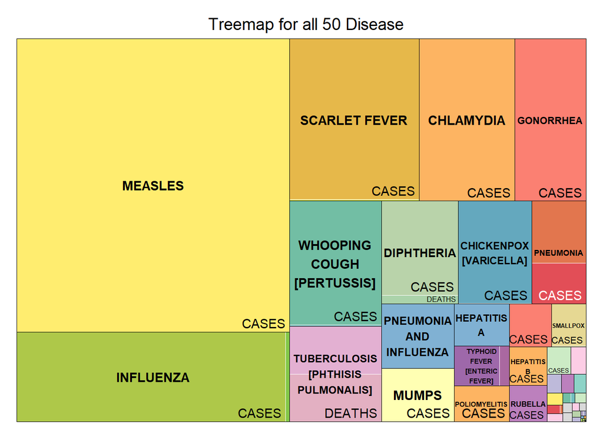

```r
# Tree map to visualize disease ratio according total event per cases and deaths
treemap(Disease, index = c("disease","event"),
        vSize = "n", vColor = "event", type = "index", bg.labels = 0,
        title = "  Treemap for all 50 Disease", border.col = c("black", "white"),
        border.lwds = c(0.7,0.5), palette = ("Set3"),
        align.labels = list(c("center","center"),c("right","bottom")))
```

Here, the Treemap shows how the spread of disease varies in terms of magnitude in relation to one another. The most prevalent diseases are shown in the largest quadrilateral region, whilst the least prevalent diseases are shown in the smallest quadrilateral. Additionally, it provides an explanation for two events—cases and deaths—in terms of the occurrence ratio.

Here is one problem from data, for some disease don’t have records for cases, Only deaths are there for example “CHOLERA” and in reverse there is 0 death against huge cases of 4928414 for “CHLAMYDIA”. Just for notice deaths of chlamydia in USA could be checked here [2] (https://www.getargon.io/posts/health/conditions/us-std/death-rate-chlamydia-us/)

```r
State <- Tycho %>% count(state,event, wt = number) # sum for all cases and deaths in each state
State <- State %>% pivot_wider(
  names_from = event,
  values_from = n,
  values_fill = 0,
  values_fn = list(breaks = mean)) # converting rows to column
```

It is time to understand the total cases for all periods in 50 states with all diseases.

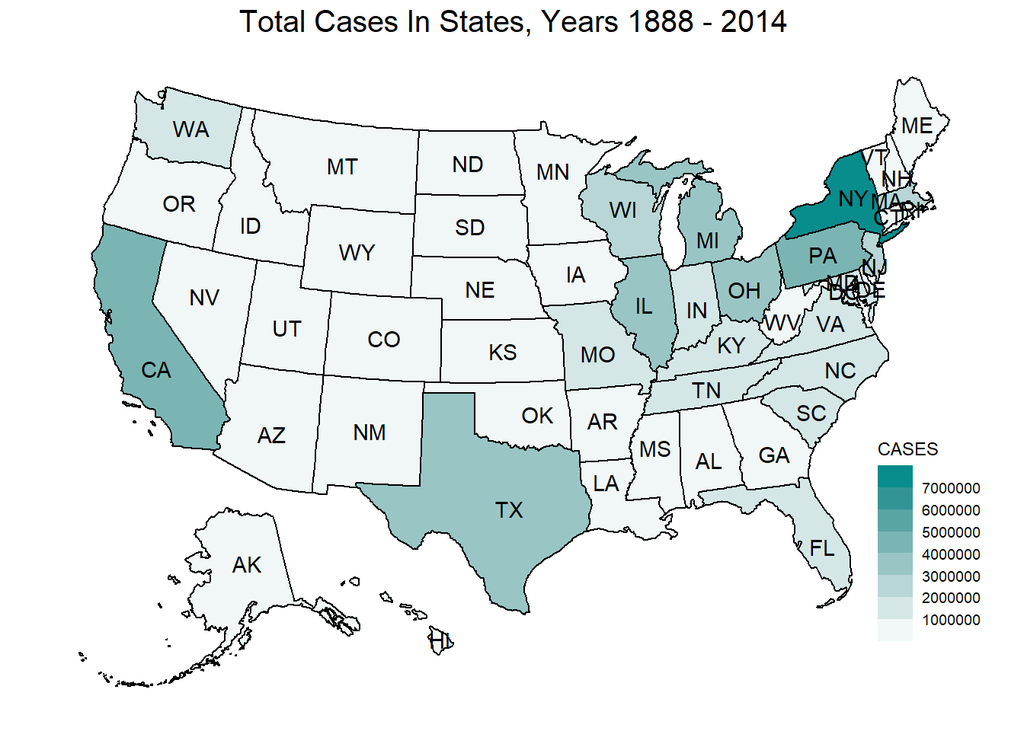

```r
# Geographic_map plot of US states to see the ratio of cases per each state
plot_usmap(data = State,values = "CASES",labels = TRUE) +  # color of graph
  scale_fill_stepsn(n.breaks = 9, colors = c("white","cyan4")) +
  ggtitle("Total Cases In States, Years 1888 - 2014") +
  theme(plot.title = element_text(size = 15, hjust = 0.5), legend.position = c(0.87, 0.1))  # title arrangements
```

The picture up top only shows casees. In order to determine if the data is dispersed throughout all states or not, it is suggested that death rates for all diseases combined be compared for each state in the United States. The concept that a rise in cases will result in a rise in fatalities is maintained by comparing cases and deaths for each state, although certain states (WI, WA) don’t follow this practice, leading us to believe that the occurrence of high fatality diseases is uneven.

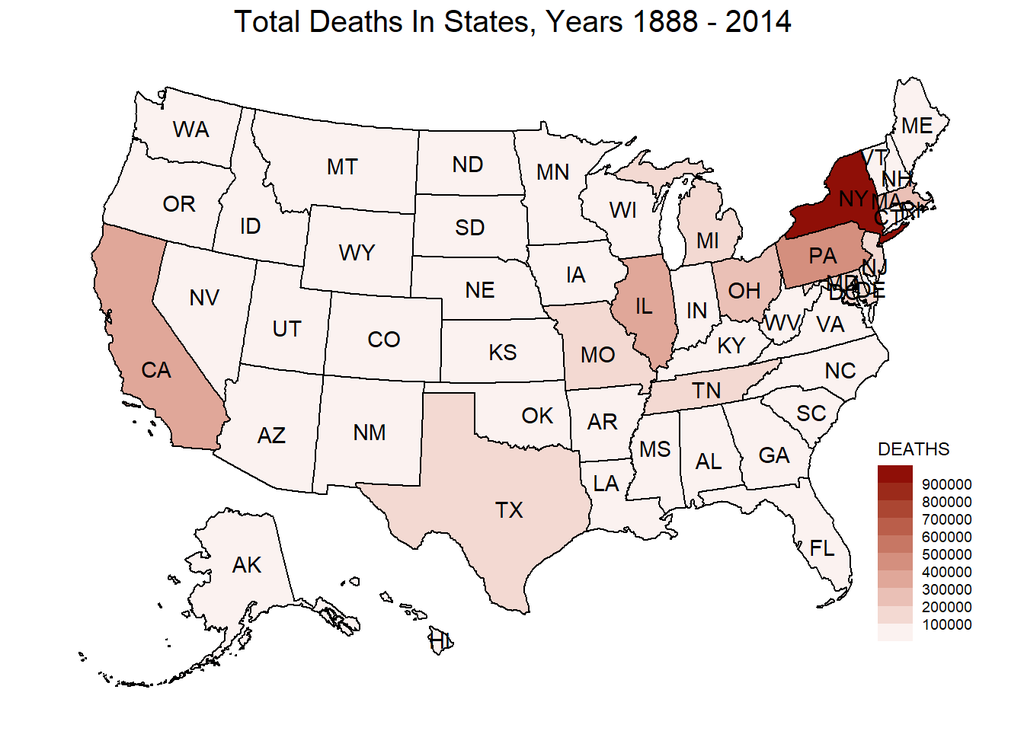

```r
# Geographic_map plot of US states to see the ratio of deaths per each state
plot_usmap(data = State, values = "DEATHS",labels = TRUE) +
  scale_fill_stepsn(n.breaks = 9,colors = c("white","darkred")) +  # color of graph
  ggtitle("Total Deaths In States, Years 1888 - 2014") + # title arrangements
  theme(plot.title = element_text(size = 15, hjust = 0.5), legend.position = c(0.87, 0.1))
```

Following the visualization of state-level data, it is stated that our data only provides a broad overview of the overall number of disease-related events on a state-level. Therefore, it is wise to investigate each disease’s contribution to cases and fatalities. The study question will be made more comprehensive with the help of the depiction of the number of cases and fatalities.

```r
# filtering disease which is grater than 50,000.
Disease1 <- Disease %>% pivot_wider(names_from = event, values_from = n, values_fill = 0) # creates Disease1 which has separate deaths and cases column
Disease1 <- Disease1 %>% group_by(DEATHS,CASES) %>% filter(CASES  >= 55000 | DEATHS > 60000) # filtering cases and death
Disease1 <- Disease1 %>% pivot_longer( cols = DEATHS : CASES, names_to = "event", values_to = "number") # Changing back as before
```

The data is divided into cases and deaths using the aforementioned code, where cases must total greater than 55,000.

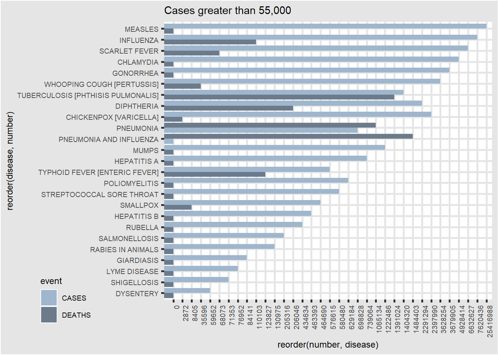

```r
## Bar plot for comparing each disease with cases and deaths which are grater than 55,000
ggplot(Disease1, aes(x = reorder(disease, number) , y = reorder(number, disease),  fill= event))+
  geom_bar( position='dodge', stat='identity', ) + coord_flip()+ theme_igray() +
  scale_fill_manual( values = c("slategray3", "slategray4"),labels = c("CASES","DEATHS")) +
  theme(text = element_text(size = 9),element_line(size =1),legend.position = c(-0.3, 0.0),axis.text.x = element_text(angle = 90, hjust = 1)) +
  ggtitle("Cases greater than 55,000")
```

The graphic shown above compares the number of cases and fatalities for each disease in the United States for the relevant time frames. There are exactly half (25) of the diseases that fall within the group of diseases with more than 55000 cases.

```r
# filtering disease which is lower than 50,000.
Disease2 <- Disease %>% pivot_wider(
  names_from = event,
  values_from = n,
  values_fill = 0) # creates Disease1 which has separate deaths and cases column
Disease2 <- Disease2 %>% group_by(DEATHS,CASES) %>% filter(CASES <= 50000 & disease != "PNEUMONIA AND INFLUENZA") # filtering cases and death and skip "PNEUMONIA AND INFLUENZA" from the selection because took already in Disease1.

Disease2 <- Disease2 %>% pivot_longer( cols = DEATHS : CASES, names_to = "event", values_to = "number")
```

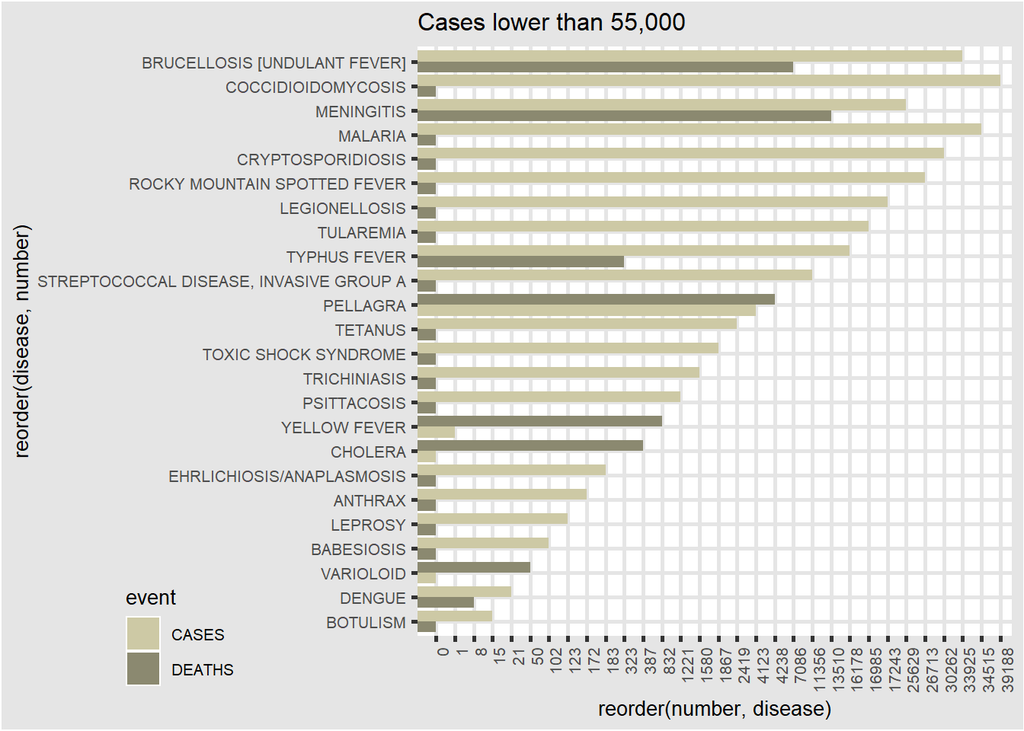

```r
# Bar plot for comparing each disease with cases and deaths which are lower than 50,000
ggplot(Disease2, aes(x = reorder(disease, number) , y = reorder(number, disease), fill= event))+
  geom_bar( position='dodge', stat='identity') + coord_flip()+ theme_igray() +
  scale_fill_manual(values = c("lemonchiffon3", "lemonchiffon4"),labels = c("CASES","DEATHS")) +
  theme(text = element_text(size = 10),element_line(size =1),legend.position = c(-0.4, 0.0),axis.text.x = element_text(angle = 90, hjust = 1)) +
  ggtitle("Cases lower than 55,000")
```

```r
# converting Disease and filtering the disease which only has cases and deaths.
Case_n_Death <- Disease %>% pivot_wider(names_from = event, values_from = n, values_fill = 0)
Case_n_Death <- Case_n_Death %>% group_by(CASES,DEATHS) %>% filter(CASES  >= 1 & DEATHS >= 1 )
Case_n_Death <- Case_n_Death %>%  pivot_longer( cols = DEATHS : CASES, names_to = "event", values_to = "number")
```

There are 15 diseases that have records of both cases and deaths, as seen in the two bar charts above. This raises the question of which sickness is the most deadly of the 50 diseases and has a high mortality rate relative to cases. That might be achieved by a box-plot illustration.

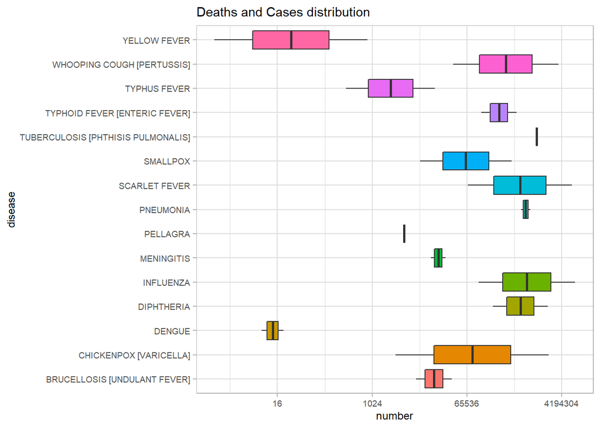

```r
# Box plot to shows the mean values of each diseases in comparison of deaths for cases
ggplot(Case_n_Death, aes(x=number, y=disease, fill=disease)) + theme_light() +
  geom_boxplot() + xscale("log2", .format = FALSE) + theme(legend.position = "none") + theme(text = element_text(size = 9),element_line(size =1)) + ggtitle("Deaths and Cases distribution")
```

```r
State_death_count <- filter (Tycho, event == "DEATHS") # filtering only deaths using state column (2)number from Tycho
State_death_count <- State_death_count %>%  group_by(state, disease) %>% summarise(number = sum(number))
State_cases_count <- filter (Tycho, event == "CASES") # filtering only deaths using state column (2)number from Tycho
State_cases_count <- State_cases_count %>%  group_by(state, disease) %>% summarise(number = sum(number))
```

The data is adjusted in the following two code chunks, one for deaths and the other for cases, such that the data is grouped according to specific intervals and may be seen as a heat map.

```r
State_death_count$groups <- cut(State_death_count$number, breaks = c(0,10,100,1000,10000,100000,500000)) # Creating Group of number of death for heat_map to create scale
```

```r
State_cases_count$groups <- cut(State_cases_count$number, breaks = c(0,100,1000,10000,100000,1000000,5000000)) # Creating Group of number of cases for heat_map to create scale
```

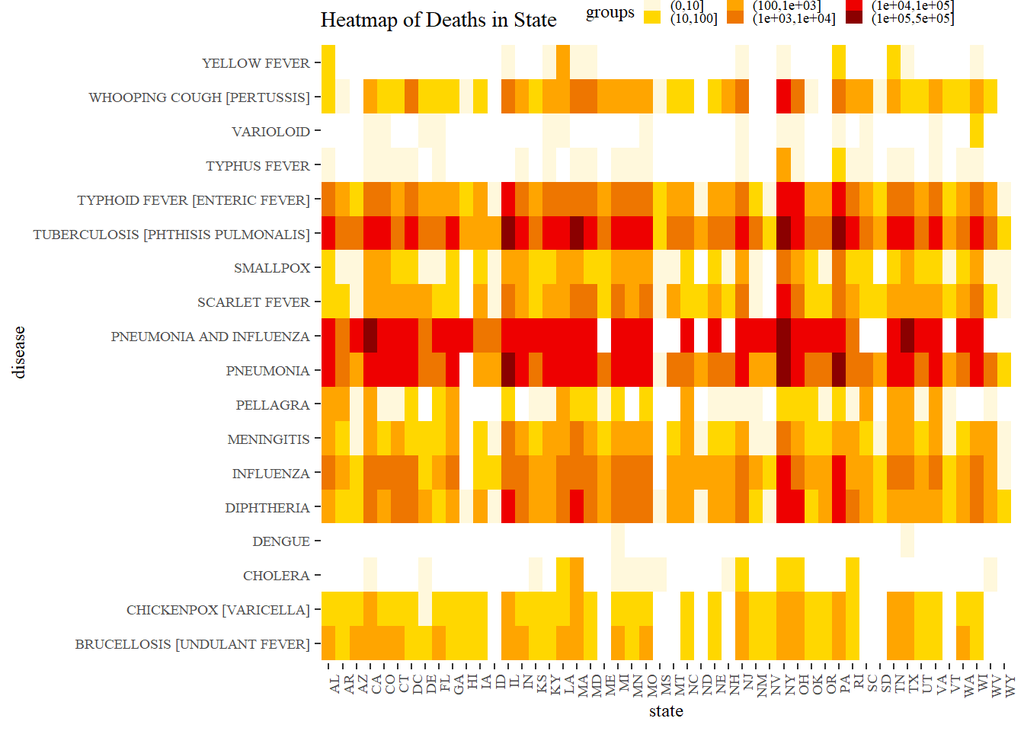

```r
# Heat_map for deaths on the basis of ranges(0-10,10-100,100-1000...) which shows the concentration of the deaths per state.
ggplot(State_death_count, aes(state,disease)) +
  geom_tile(aes(fill= groups)) + # Border color
  scale_fill_manual(breaks = levels(State_death_count$groups), values = c("cornsilk","gold","orange","darkorange2","red2","darkred")) + # Box color low to high
  theme_tufte() + # plot theme
  theme(text = element_text(size = 9),axis.text.x = element_text(angle = 90, hjust = 1)) + # text size arrangement of scales
 theme(legend.key.width = unit(0.3, "cm"), legend.key.height = unit(0.2, "cm"),legend.direction = 'horizontal', legend.position = c(0.65, 1.05)) +
  ggtitle("Heatmap of Deaths in State" )
```

The heat map shows how three diseases—tuberculosis, influenza, and pneumonia—had a significant influence on almost all states. Additionally, it was discovered that yellow fever, dengue, cholera, varioloid, and typhus fever had the least influence.

The intensity of the number of cases for all diseases in the states of the United States is shown in the heat map below. The heat map shows that Anthrax, Babesiosis, Leprosy, Dengue, Coccidioidomycosis, Ehrlichiosis/Anaplasmosis, and Yellow Fever are the diseases that are least affected throughout all states. Measles, influenza, hepatitis B, hepatitis A, gonorrhea, whooping cough, chlamydia, and chicken pox are the illnesses that have the most impact..

In this heat map, it can also be see that five states—American Samoa (AS), Guam (GU), MP, PT, and Virgin Islands—had less impact on the number of cases than the other states (VI).

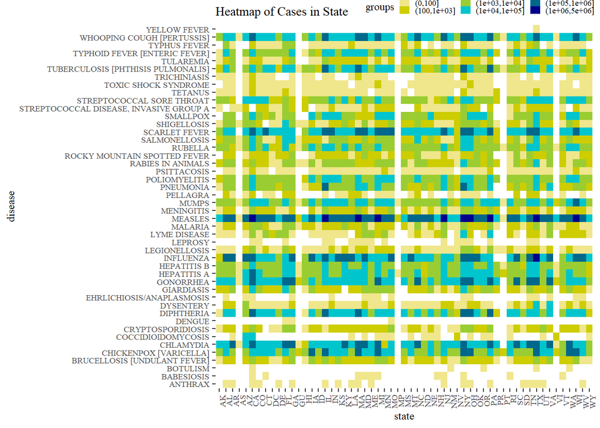

```r
# Heat_map for cases on the basis of ranges(0-100,100-1000,1000-10000...) which shows the concentration of the cases per state.
ggplot(State_cases_count, aes(state, disease )) +
  geom_tile(aes(fill= groups ) ) +
  scale_fill_manual(breaks = levels(State_cases_count$groups),  values = c("khaki","yellow3","olivedrab3","turquoise3","deepskyblue4","darkblue","mediumseagreen2")) +
  theme_tufte() + # plot theme
  theme(text = element_text(size = 9),axis.text.x = element_text(angle = 90, hjust = 1)) +
  theme(legend.key.width = unit(0.3, "cm"), legend.key.height = unit(0.2, "cm"),legend.direction = 'horizontal', legend.position = c(0.7, 1.05)) +
  ggtitle("Heatmap of Cases in State" ) # plot title
```

```r
# White space shows there are no cases for particular disease for related states
```

The next steps is going to focus on the specific research question of this work that is to find out the effect of Measles in the states of U.S, by filtering specific data by decades and that will showcase the effects of Measles in each decade.

```r
# Here filtering the Measles according each decade,to combine it at the end.
Y1915 <- Tycho %>% filter(disease == "MEASLES") %>% group_by(state,number) %>% filter(from_date >= as.Date("1905-01-01")  & from_date < as.Date("1915-01-01"))  %>%  select(state, number) %>% ungroup(state,number) %>% group_by(state) %>% count(state, wt = number) %>% add_column(year = "1905")

Y1925 <- Tycho %>% filter(disease == "MEASLES") %>% group_by(state,number) %>% filter(from_date >= as.Date("1915-01-01")  & from_date < as.Date("1925-01-01")) %>% select(state, number) %>% ungroup(state,number) %>% group_by(state) %>% count(state, wt = number) %>% add_column(year = "1915")

Y1935 <- Tycho %>% filter(disease == "MEASLES") %>% group_by(state,number) %>% filter(from_date >= as.Date("1925-01-01")  & from_date < as.Date("1935-01-01")) %>% select(state, number) %>% ungroup(state,number) %>% group_by(state) %>% count(state, wt = number) %>% add_column(year = "1925")

Y1945 <- Tycho %>% filter(disease == "MEASLES") %>% group_by(state,number) %>% filter(from_date >= as.Date("1935-01-01")  & from_date < as.Date("1945-01-01")) %>% select(state, number) %>% ungroup(state,number) %>% group_by(state) %>% count(state, wt = number) %>% add_column(year = "1935")

Y1955 <- Tycho %>% filter(disease == "MEASLES") %>% group_by(state,number) %>% filter(from_date >= as.Date("1945-01-01")  & from_date < as.Date("1955-01-01")) %>% select(state, number) %>% ungroup(state,number) %>% group_by(state) %>% count(state, wt = number) %>% add_column(year = "1945")

Y1965 <- Tycho %>% filter(disease == "MEASLES") %>% group_by(state,number) %>% filter(from_date >= as.Date("1955-01-01")  & from_date < as.Date("1965-01-01")) %>% select(state, number) %>% ungroup(state,number) %>% group_by(state) %>% count(state, wt = number) %>% add_column(year = "1955")

Y1975 <- Tycho %>% filter(disease == "MEASLES") %>% group_by(state,number) %>% filter(from_date >= as.Date("1965-01-01")  & from_date < as.Date("1975-01-01")) %>% select(state, number) %>% ungroup(state,number) %>% group_by(state) %>% count(state, wt = number) %>% add_column(year = "1965")

Y1985 <- Tycho %>% filter(disease == "MEASLES") %>% group_by(state,number) %>% filter(from_date >= as.Date("1975-01-01")  & from_date < as.Date("1985-01-01")) %>% select(state, number) %>% ungroup(state,number) %>% group_by(state) %>% count(state, wt = number) %>% add_column(year = "1975")

Y1995 <- Tycho %>% filter(disease == "MEASLES") %>% group_by(state,number) %>% filter(from_date >= as.Date("1985-01-01")  & from_date < as.Date("1995-01-01")) %>% select(state, number) %>% ungroup(state,number) %>% group_by(state) %>% count(state, wt = number) %>% add_column(year = "1985")

Y2005 <- Tycho %>% filter(disease == "MEASLES") %>% group_by(state,number) %>% filter(from_date >= as.Date("1995-01-01")  & from_date < as.Date("2005-01-01")) %>% select(state, number) %>% ungroup(state,number) %>% group_by(state) %>% count(state, wt = number) %>% add_column(year = "1995")
```

```r
# Combining the decade from 1915-2005 for measles disease
Measles_decade <- rbind(Y1915,Y1925,Y1935,Y1945,Y1955,Y1965,Y1975,Y1985,Y1995,Y2005) # Combining all decades to new data frame
Measles_decade$year <- as.integer(Measles_decade$year)
```

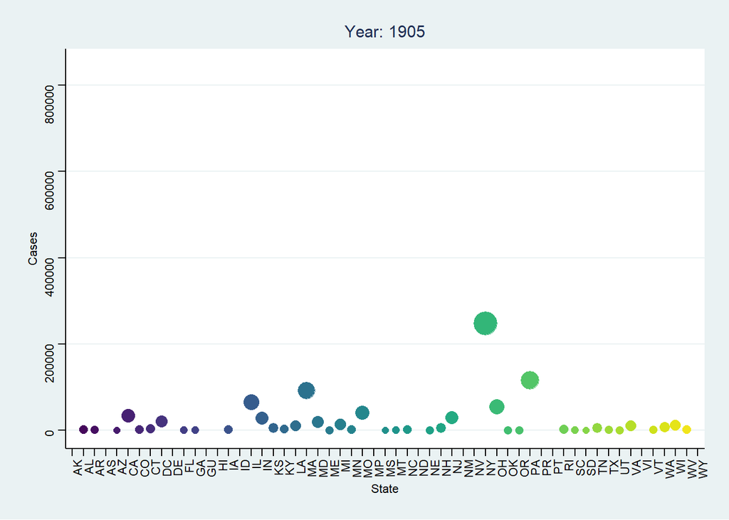

```r
# Animation plot to catch the trend of disease per each state
ggplot(Measles_decade, aes( x = state, y = n, size = n, color = state)) +
  geom_point(alpha = 1.0, show.legend = FALSE  ) +
  scale_color_viridis_d() + theme_stata() +
  theme(plot.title = element_text(hjust = 0.5)) +
  theme(text = element_text(size = 9),axis.text.x = element_text(angle = 90, hjust = 1)) +
  theme(legend.position = "none") + scale_size(range = c(2, 12)) +
  labs(title = 'Year: {frame_time}', x = 'State', y = 'Cases') + transition_time(year)
```

According to the animation plot shown above, measles cases increased exponentially from a low level in 1905 to a peak around 1936. Thereafter, cases gradually declined until the measles vaccine was released in the US in 1962, at which point they abruptly began to decline.

# Results

Using the data from the Tycho Project, as described in the problem discussion section, the motive was looking for the disease that has impacted the states of the United States the most frequently.

Measles was discovered to have a much greater impact than other illnesses (from tree map). And the data demonstrates that New York had the greatest impact in terms of incidents and fatalities. Measles, influenza, scarlet fever, chlamydia, and gonorrhea are shown to be the top five dangerous diseases when just cases are taken into account.

However, the survival rates of people with tuberculosis, pneumonia, pellagra, and meningitis are incredibly low, making them the most deadly illnesses.

# Discussion

The U.S. health department’s data was almost spotless and contained state names, dates, and times in their entirety. The numbers were further divided into events that distinguished between cases and deaths and also included city and state names, which required less filtering to obtain meaningful insights from the data. The data’s precise weekly time periods supported analysis based on consecutive events.

There are no missing values in the case of the actual data, but from deeper examination, it can be seen that several diseases’ death statistics are missing from the data. chlamydia, gonorrhea, measles, mumps, and rubella, to name a few. However, certain diseases only have death statistics. Take Cholera, Varioloid, pneumonia, and influenza, as examples.

The research’s findings indicated that measles was the most prevalent disease when only cases were taken into account; however, if data on deaths had been included, the methodology might have produced more precise predictions of mortality attributable to measles.

# Conclusion

After performing this graphical analysis it can be concluded that many diseases like Pneumonia, Tuberculosis, Pellagra and Meningitis had high fatality effect in the U.S, But Measles is the most abundant one among all 50 from the data.

# Refrences

Project Tycho 2.0 Data (https://www.tycho.pitt.edu/version-2/)

Measles data (https://www.cdc.gov/measles/vaccination.html)

Life expectancy in U.S (https://www.healthypeople.gov/2020/about/foundation-health-measures/General-Health-Status)